# Easy Way #2

This example uses the ipeds library to carry out a simple regression analysis involving data from about half a dozen different IPEDS surveys from the same year. It is intended to investigate the impact of a quarter calendar system on graduation rates. It is a rather silly analysis, however, and should be regarded as demonstration of what *can* be done with the package, not perhaps what *should* be done with the package.

We’ll use these IVs in our analysis:

- Size of graduation cohort
- Selectivity of the institution
- Tuition $
- Control (public/private)
- Locale (city/town/suburb/rural)
- Student:faculty ratio
- Calendar system (semester/quarter)

```r
library(ipeds)
library(tidyverse)
library(gvlma)
library(car)
library(reshape2)
dir <- "C:\\Users\\mjs26\\Documents\\data\\downloaded"
min_school_size <- 100
```

# What’s available?

Helpful for a quick reminder of the various IPEDS surveys and their abbreviations.

```r
data(surveys)
surveys %>% select(c('SurveyID','Survey','Title'))
```

|  | SurveyID | Survey | Title |
| --- | --- | --- | --- |
| 1 | HD | Institutional Characteristics | Directory information |
| 2 | IC | Institutional Characteristics | Educational offerings, organization, admissions, services and athletic associations |
| 3 | IC_AY | Institutional Characteristics | Student charges for academic year programs |
| 4 | IC_PY | Institutional Characteristics | Student charges by program (vocational programs) |
| 5 | FLAGS | Institutional Characteristics | Response status for all survey components |
| 6 | EFEST | Enrollments | Estimated enrollment |
| 7 | EFA | Enrollments | Race/ethnicity, gender, attendance status, and level of students: Fall |
| 8 | EFANR | Enrollments | Race/ethnicity, gender, attendance status, and level of students: Fall prior to 2000 |
| 9 | EFB | Enrollments | Age category, gender, attendance status, and level of student: Fall |
| 10 | EFC | Enrollments | Residence and migration of first-time freshman: Fall |

[output cut: 56 more lines]

# Get the data

We’re going to grab the survey files one at a time, merging (joining) them together by unit id as we go. The three IC files are first up:

```r
directory <- ipeds_survey(table='HD',year=2017, dir=dir)
names(directory) <- tolower(names(directory))

charges <- ipeds_survey('IC_AY', year=2017, dir=dir)
names(charges) <- tolower(names(charges))

charges = charges[,c('unitid',
 'tuition1', 'fee1', 'hrchg1',  #In-district average tuition for full-time undergraduates
 'tuition2', 'fee2', 'hrchg2',  #In-state average tuition for full-time undergraduates
 'tuition3', 'fee3', 'hrchg3',  #Out-of-state average tuition for full-time undergraduates
 'tuition5', 'fee5', 'hrchg5', #In-district average tuition full-time graduates
 'tuition6', 'fee6', 'hrchg6', #In-state average tuition full-time graduates
 'tuition7', 'fee7', 'hrchg7')] #Out-of-state average tuition full-time graduates

dirCharges = merge(charges, directory, by='unitid', all.x=TRUE)

ic <- ipeds_survey(table='IC',year=2017, dir=dir)
names(ic) <- tolower(names(ic))

dirCharges <- merge(dirCharges, ic, by='unitid', all.x=TRUE)
```

Then Admissions:

```r
admissions <- ipeds_survey(table='ADM',year=2017, dir=dir)
names(admissions) <- tolower(names(admissions))
```

Graduation rates:

```r
gradrates <- (ipeds_survey('GR',year=2017, dir=dir))
names(gradrates) <- tolower(names(gradrates))
gradrates <- gradrates[which(gradrates$grtype %in% c(2,3)),]

# extract the 150% graduation rate
theRates <- dcast(gradrates, unitid ~ grtype, value.var = 'grtotlt')
names(theRates) <- c('unitid','adjusted_cohort','completers')
theRates$rate <- theRates$completers/theRates$adjusted_cohort
```

Eliminate any schools with missing graduation rates:

```r
theRates <- theRates[which(!is.na(theRates$rate)),]
```

And any with less than 100 in the grad rate cohort

```r
d1 <- merge(dirCharges, theRates, by='unitid', all.y=TRUE)
d1 <- d1[which(d1$calsys %in% c(1,2)),]
d1$calsys <- as.factor(d1$calsys)
levels(d1$calsys) <- c('Semester','Quarter')
d1 <- d1[which(d1$adjusted_cohort > min_school_size),]
```

IPEDS Admissions gives us selectivity.

```r
d1 <- merge(d1, admissions, by='unitid', all.x=TRUE)
d1$select <- d1$admssn / d1$applcn
```

Here’s Fall Enrollment, which is where student:faculty ratio lives.

```r
fallenr <- ipeds_survey(table='EFD', year=2017, dir=dir)
names(fallenr) <- tolower(names(fallenr))
d1 <- merge(d1, fallenr, by='unitid', all.x=TRUE)
d1 <- d1[which(!is.na(d1$stufacr)),] # remove any schools with missing s:f ratio
```

That’s all the data we need. Do our continuous variables have sensible shapes?

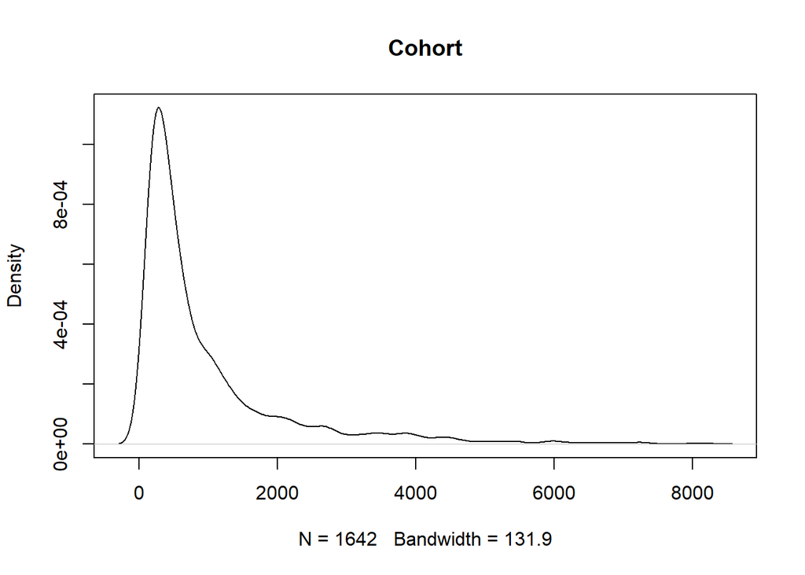

```r
plot(density(d1$adjusted_cohort), main="Cohort")
```

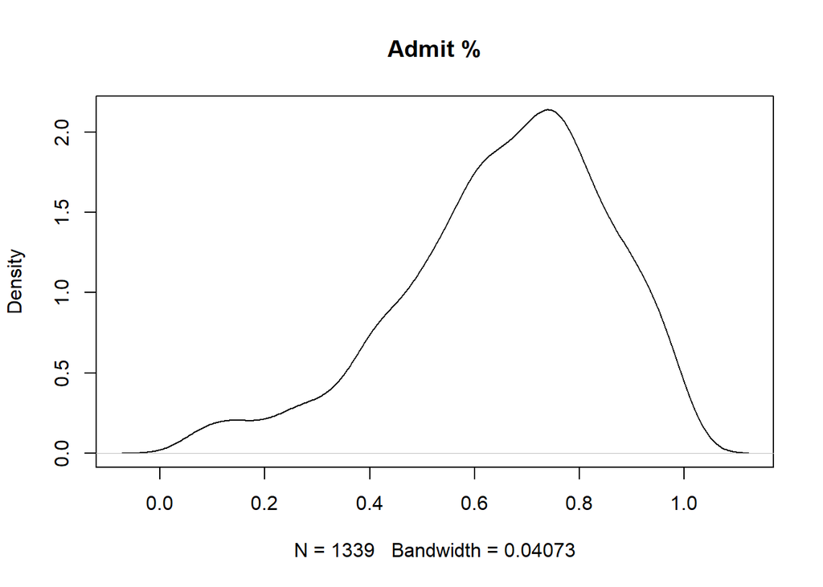

```r
plot(density(d1[which(!is.na(d1$select)),]$select), main="Admit %")
```

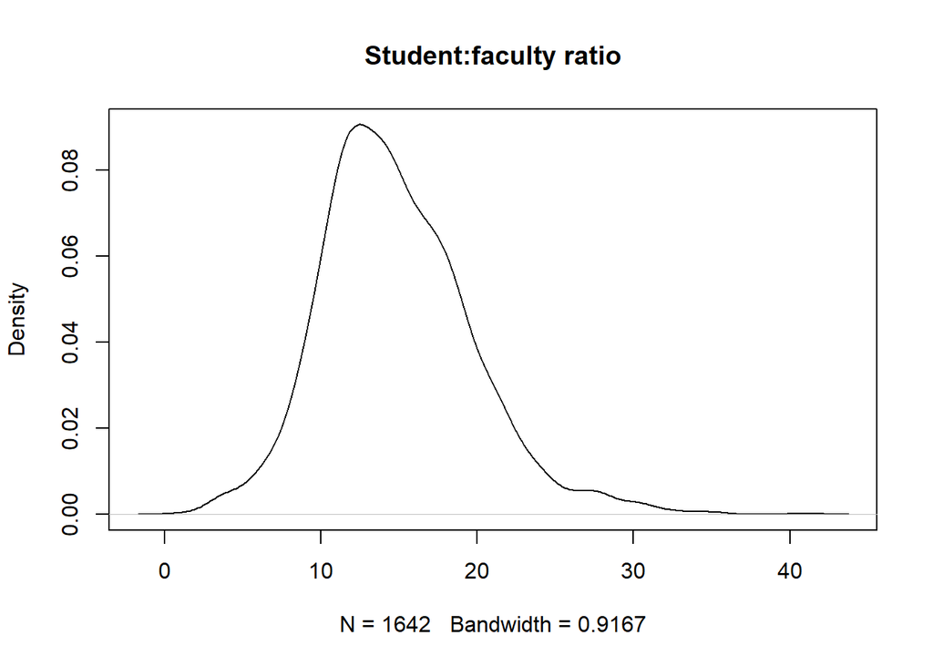

```r
plot(density(d1$stufacr), main="Student:faculty ratio")
```

```r
table(d1$calsys,d1$control)
```

```
##
##              1   2   3
##   Semester 625 802  52
##   Quarter   50  29  84
```

This code chunk recodes IPEDS’ locale codes into something more readable.

```r
d1$locale2 <- substr(d1$locale,1,1)
d1$locale2 <- as.factor(d1$locale2)
levels(d1$locale2) <- c('City','Town','Suburb','Rural')
table(d1$locale2, d1$locale)
```

```
##
##           11  12  13  21  22  23  31  32  33  41  42  43
##   City   366 209 234   0   0   0   0   0   0   0   0   0
##   Town     0   0   0 315  51  36   0   0   0   0   0   0
##   Suburb   0   0   0   0   0   0  57 163 112   0   0   0
##   Rural    0   0   0   0   0   0   0   0   0  57  25  17
```

# Model and output

```r
theLM <- lm(rate ~ calsys + as.integer(tuition1) + control + select + stufacr + locale2  + adjusted_cohort, data=d1, family=gaussian)
summary(theLM)
```

```
##
## Call:
## lm(formula = rate ~ calsys + as.integer(tuition1) + control +
##     select + stufacr + locale2 + adjusted_cohort, data = d1,
##     family = gaussian)
##
## Residuals:
##      Min       1Q   Median       3Q      Max
## -0.48337 -0.07656  0.00349  0.07163  0.51467
##
## Coefficients:
##                        Estimate Std. Error t value Pr(>|t|)
## (Intercept)           5.297e-01  2.572e-02  20.592  < 2e-16 ***
## calsysQuarter         5.952e-02  1.607e-02   3.703 0.000222 ***
## as.integer(tuition1)  9.753e-06  3.946e-07  24.718  < 2e-16 ***
## control              -8.916e-02  9.550e-03  -9.336  < 2e-16 ***
## select               -1.083e-01  1.777e-02  -6.092 1.45e-09 ***
## stufacr              -3.071e-03  1.033e-03  -2.972 0.003016 **
## locale2Town           3.518e-02  8.279e-03   4.249 2.30e-05 ***
## locale2Suburb         1.107e-02  8.895e-03   1.245 0.213466
## locale2Rural         -2.757e-02  1.537e-02  -1.794 0.073044 .
## adjusted_cohort       5.909e-05  3.471e-06  17.025  < 2e-16 ***
## ---
## Signif. codes:  0 '***' 0.001 '**' 0.01 '*' 0.05 '.' 0.1 ' ' 1
##
## Residual standard error: 0.1203 on 1326 degrees of freedom
##   (306 observations deleted due to missingness)
## Multiple R-squared:  0.5646, Adjusted R-squared:  0.5617
## F-statistic: 191.1 on 9 and 1326 DF,  p-value: < 2.2e-16
```

```r
library(gvlma)
gvlma(theLM)
```

```
##
## Call:
## lm(formula = rate ~ calsys + as.integer(tuition1) + control +
##     select + stufacr + locale2 + adjusted_cohort, data = d1,
##     family = gaussian)
##
## Coefficients:
##          (Intercept)         calsysQuarter  as.integer(tuition1)
##            5.297e-01             5.952e-02             9.753e-06
##              control                select               stufacr
##           -8.916e-02            -1.083e-01            -3.071e-03
##          locale2Town         locale2Suburb          locale2Rural
##            3.518e-02             1.107e-02            -2.757e-02
##      adjusted_cohort
##            5.909e-05
##
##
## ASSESSMENT OF THE LINEAR MODEL ASSUMPTIONS
## USING THE GLOBAL TEST ON 4 DEGREES-OF-FREEDOM:
## Level of Significance =  0.05
##
## Call:
##  gvlma(x = theLM)
##
##                     Value   p-value                   Decision
## Global Stat        26.007 3.155e-05 Assumptions NOT satisfied!
## Skewness            1.136 2.864e-01    Assumptions acceptable.
## Kurtosis           21.549 3.449e-06 Assumptions NOT satisfied!
## Link Function       3.132 7.677e-02    Assumptions acceptable.
## Heteroscedasticity  0.189 6.637e-01    Assumptions acceptable.
```

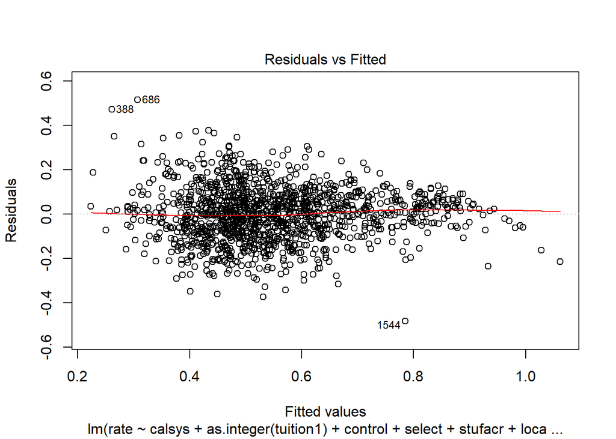

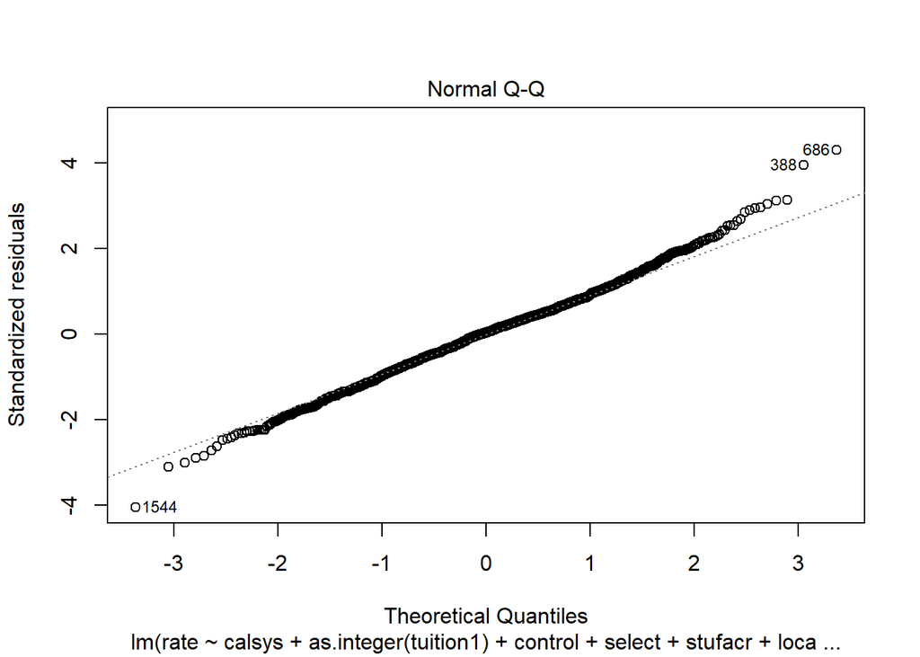

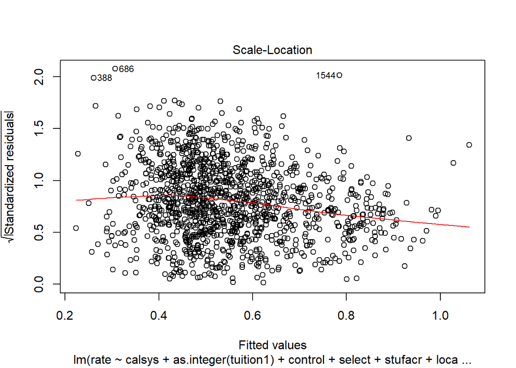

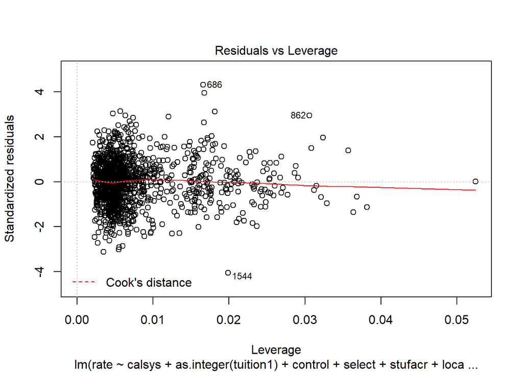

```r
plot(theLM)
```

```r
vif(theLM)
```

```
##                          GVIF Df GVIF^(1/(2*Df))
## calsys               1.022104  1        1.010992
## as.integer(tuition1) 2.943326  1        1.715612
## control              2.451026  1        1.565575
## select               1.117419  1        1.057080
## stufacr              1.871449  1        1.368009
## locale2              1.141902  3        1.022362
## adjusted_cohort      1.592042  1        1.261761
```